# Employee Attrition

## About Dataset

Uncover the factors that lead to employee attrition and explore important questions such as ‘show me a breakdown of distance from home by job role and attrition’ or ‘compare average monthly income by education and attrition’. This is a fictional data set created by IBM data scientists.

**Education**  
1 ‘Below College’, 2 ‘College’, 3 ‘Bachelor’, 4 ‘Master’, 5 ‘Doctor’

**EnvironmentSatisfaction**  
1 ‘Low’, 2 ‘Medium’, 3 ‘High’, 4 ‘Very High’

**JobInvolvement**  
1 ‘Low’, 2 ‘Medium’, 3 ‘High’, 4 ‘Very High’

**JobSatisfaction**  
1 ‘Low’, 2 ‘Medium’, 3 ‘High’, 4 ‘Very High’

**PerformanceRating**  
1 ‘Low’, 2 ‘Good’, 3 ‘Excellent’, 4 ‘Outstanding’

**RelationshipSatisfaction**  
1 ‘Low’, 2 ‘Medium’, 3 ‘High’, 4 ‘Very High’

**WorkLifeBalance**  
1 ‘Bad’, 2 ‘Good’, 3 ‘Better’, 4 ‘Best’

### Load Dataset

```r
# Read Dataset
df_raw = read.csv("D:/Kuliah/Semester 1/Statistika dan Analisis Multivariat/Tugas Besar/WA_Fn-UseC_-HR-Employee-Attrition.csv")
```

### Inspect Dataset

```r
head(df_raw)
```

```
##   Age Attrition    BusinessTravel DailyRate             Department
## 1  41       Yes     Travel_Rarely      1102                  Sales
## 2  49        No Travel_Frequently       279 Research & Development
## 3  37       Yes     Travel_Rarely      1373 Research & Development
## 4  33        No Travel_Frequently      1392 Research & Development
## 5  27        No     Travel_Rarely       591 Research & Development
## 6  32        No Travel_Frequently      1005 Research & Development
##   DistanceFromHome Education EducationField EmployeeCount EmployeeNumber
## 1                1         2  Life Sciences             1              1
## 2                8         1  Life Sciences             1              2
## 3                2         2          Other             1              4
## 4                3         4  Life Sciences             1              5
## 5                2         1        Medical             1              7
## 6                2         2  Life Sciences             1              8
##   EnvironmentSatisfaction Gender HourlyRate JobInvolvement JobLevel
```

[output cut: 41 more lines]

```r
str(df_raw)
```

```
## 'data.frame':    1470 obs. of  35 variables:
##  $ Age                     : int  41 49 37 33 27 32 59 30 38 36 ...
##  $ Attrition               : chr  "Yes" "No" "Yes" "No" ...
##  $ BusinessTravel          : chr  "Travel_Rarely" "Travel_Frequently" "Travel_Rarely" "Travel_Frequently" ...
##  $ DailyRate               : int  1102 279 1373 1392 591 1005 1324 1358 216 1299 ...
##  $ Department              : chr  "Sales" "Research & Development" "Research & Development" "Research & Development" ...
##  $ DistanceFromHome        : int  1 8 2 3 2 2 3 24 23 27 ...
##  $ Education               : int  2 1 2 4 1 2 3 1 3 3 ...
##  $ EducationField          : chr  "Life Sciences" "Life Sciences" "Other" "Life Sciences" ...
##  $ EmployeeCount           : int  1 1 1 1 1 1 1 1 1 1 ...
##  $ EmployeeNumber          : int  1 2 4 5 7 8 10 11 12 13 ...
##  $ EnvironmentSatisfaction : int  2 3 4 4 1 4 3 4 4 3 ...
##  $ Gender                  : chr  "Female" "Male" "Male" "Female" ...
##  $ HourlyRate              : int  94 61 92 56 40 79 81 67 44 94 ...
##  $ JobInvolvement          : int  3 2 2 3 3 3 4 3 2 3 ...
```

[output cut: 21 more lines]

### Check for Null Value

```r
lapply(df_raw,function(x) { length(which(is.na(x)))})
```

```
## $Age
## [1] 0
##
## $Attrition
## [1] 0
##
## $BusinessTravel
## [1] 0
##
## $DailyRate
## [1] 0
##
## $Department
## [1] 0
##
## $DistanceFromHome
## [1] 0
##
## $Education
## [1] 0
##
## $EducationField
## [1] 0
##
## $EmployeeCount
## [1] 0
##
## $EmployeeNumber
## [1] 0
##
## $EnvironmentSatisfaction
## [1] 0
##
## $Gender
## [1] 0
##
## $HourlyRate
## [1] 0
##
## $JobInvolvement
```

[output cut: 49 more lines]

```
##
## $WorkLifeBalance
## [1] 0
##
## $YearsAtCompany
## [1] 0
##
## $YearsInCurrentRole
## [1] 0
##
## $YearsSinceLastPromotion
## [1] 0
##
## $YearsWithCurrManager
## [1] 0
```

```r
df_clean = df_raw
```

### Drop categorical column

```r
library(psych)

ints<-sapply(df_clean, is.integer)

df_clean_int = as.data.frame(apply(df_clean[,ints],2,as.numeric))
df_clean_int = df_clean_int[c(-4,-7,-10, -11, -16, -17, -22)]
str(df_clean_int)
```

```
## 'data.frame':    1470 obs. of  19 variables:
##  $ Age                    : num  41 49 37 33 27 32 59 30 38 36 ...
##  $ DailyRate              : num  1102 279 1373 1392 591 ...
##  $ DistanceFromHome       : num  1 8 2 3 2 2 3 24 23 27 ...
##  $ EmployeeCount          : num  1 1 1 1 1 1 1 1 1 1 ...
##  $ EmployeeNumber         : num  1 2 4 5 7 8 10 11 12 13 ...
##  $ HourlyRate             : num  94 61 92 56 40 79 81 67 44 94 ...
##  $ JobInvolvement         : num  3 2 2 3 3 3 4 3 2 3 ...
##  $ MonthlyIncome          : num  5993 5130 2090 2909 3468 ...
##  $ MonthlyRate            : num  19479 24907 2396 23159 16632 ...
##  $ NumCompaniesWorked     : num  8 1 6 1 9 0 4 1 0 6 ...
##  $ PercentSalaryHike      : num  11 23 15 11 12 13 20 22 21 13 ...
##  $ StandardHours          : num  80 80 80 80 80 80 80 80 80 80 ...
##  $ StockOptionLevel       : num  0 1 0 0 1 0 3 1 0 2 ...
##  $ TotalWorkingYears      : num  8 10 7 8 6 8 12 1 10 17 ...
##  $ TrainingTimesLastYear  : num  0 3 3 3 3 2 3 2 2 3 ...
##  $ YearsAtCompany         : num  6 10 0 8 2 7 1 1 9 7 ...
##  $ YearsInCurrentRole     : num  4 7 0 7 2 7 0 0 7 7 ...
##  $ YearsSinceLastPromotion: num  0 1 0 3 2 3 0 0 1 7 ...
##  $ YearsWithCurrManager   : num  5 7 0 0 2 6 0 0 8 7 ...
```

### Feature Scalling

```r
#install.packages("conflicted")
library(conflicted)
conflict_prefer("apply", "base")
```

```
## [conflicted] Will prefer base::apply over any other package
```

```r
# Create Response Variable as DataFrame
df_target=as.data.frame(df_clean[c(2)])

# Norm Z function declaration
normalisasi=function(x){
  xm=colMeans(x)
  jb=dim(x)[1]
  xc=x-rep(xm,each=jb)
  sdx=apply(x,2,sd)
  xstd=xc/rep(sdx,each=jb)
  output=data.frame(xstd)
  #output=data.frame(xstd,x)
  return(output)
}


# Min-Max Norm function declaration
min_max_norm <- function(x) {
    (x - min(x)) / (max(x) - min(x))
  }

# Normalization
#df_norm = normalisasi(df_clean_int)
df_norm = as.data.frame(lapply(df_clean_int, min_max_norm))

# Outer Join Dataset
df_norm = data.frame(df_target,df_norm)

# Label encoding for response variable
df_norm$Attrition = ifelse(df_norm$Attrition=="Yes",1,0)
df_norm$Attrition = factor(df_norm$Attrition, levels = c(0,1))

summary(df_norm)
```

```
##  Attrition      Age           DailyRate      DistanceFromHome  EmployeeCount
##  0:1233    Min.   :0.0000   Min.   :0.0000   Min.   :0.00000   Min.   : NA
##  1: 237    1st Qu.:0.2857   1st Qu.:0.2598   1st Qu.:0.03571   1st Qu.: NA
##            Median :0.4286   Median :0.5011   Median :0.21429   Median : NA
##            Mean   :0.4506   Mean   :0.5014   Mean   :0.29259   Mean   :NaN
##            3rd Qu.:0.5952   3rd Qu.:0.7552   3rd Qu.:0.46429   3rd Qu.: NA
##            Max.   :1.0000   Max.   :1.0000   Max.   :1.00000   Max.   : NA
##                                                                NA's   :1470
##  EmployeeNumber     HourlyRate     JobInvolvement   MonthlyIncome
##  Min.   :0.0000   Min.   :0.0000   Min.   :0.0000   Min.   :0.0000
##  1st Qu.:0.2372   1st Qu.:0.2571   1st Qu.:0.3333   1st Qu.:0.1002
##  Median :0.4932   Median :0.5143   Median :0.6667   Median :0.2059
##  Mean   :0.4953   Mean   :0.5127   Mean   :0.5766   Mean   :0.2893
##  3rd Qu.:0.7522   3rd Qu.:0.7679   3rd Qu.:0.6667   3rd Qu.:0.3881
##  Max.   :1.0000   Max.   :1.0000   Max.   :1.0000   Max.   :1.0000
##
##   MonthlyRate     NumCompaniesWorked PercentSalaryHike StandardHours
##  Min.   :0.0000   Min.   :0.0000     Min.   :0.00000   Min.   : NA
##  1st Qu.:0.2390   1st Qu.:0.1111     1st Qu.:0.07143   1st Qu.: NA
##  Median :0.4875   Median :0.2222     Median :0.21429   Median : NA
##  Mean   :0.4906   Mean   :0.2992     Mean   :0.30068   Mean   :NaN
##  3rd Qu.:0.7375   3rd Qu.:0.4444     3rd Qu.:0.50000   3rd Qu.: NA
##  Max.   :1.0000   Max.   :1.0000     Max.   :1.00000   Max.   : NA
##                                                        NA's   :1470
##  StockOptionLevel TotalWorkingYears TrainingTimesLastYear YearsAtCompany
##  Min.   :0.0000   Min.   :0.000     Min.   :0.0000        Min.   :0.0000
##  1st Qu.:0.0000   1st Qu.:0.150     1st Qu.:0.3333        1st Qu.:0.0750
##  Median :0.3333   Median :0.250     Median :0.5000        Median :0.1250
##  Mean   :0.2646   Mean   :0.282     Mean   :0.4666        Mean   :0.1752
##  3rd Qu.:0.3333   3rd Qu.:0.375     3rd Qu.:0.5000        3rd Qu.:0.2250
##  Max.   :1.0000   Max.   :1.000     Max.   :1.0000        Max.   :1.0000
##
##  YearsInCurrentRole YearsSinceLastPromotion YearsWithCurrManager
##  Min.   :0.0000     Min.   :0.00000         Min.   :0.0000
##  1st Qu.:0.1111     1st Qu.:0.00000         1st Qu.:0.1176
##  Median :0.1667     Median :0.06667         Median :0.1765
##  Mean   :0.2350     Mean   :0.14585         Mean   :0.2425
##  3rd Qu.:0.3889     3rd Qu.:0.20000         3rd Qu.:0.4118
##  Max.   :1.0000     Max.   :1.00000         Max.   :1.0000
##
```

```r
unique(df_norm$Attrition)
```

```
## [1] 1 0
## Levels: 0 1
```

### Check Correlation Between Predictor Variables

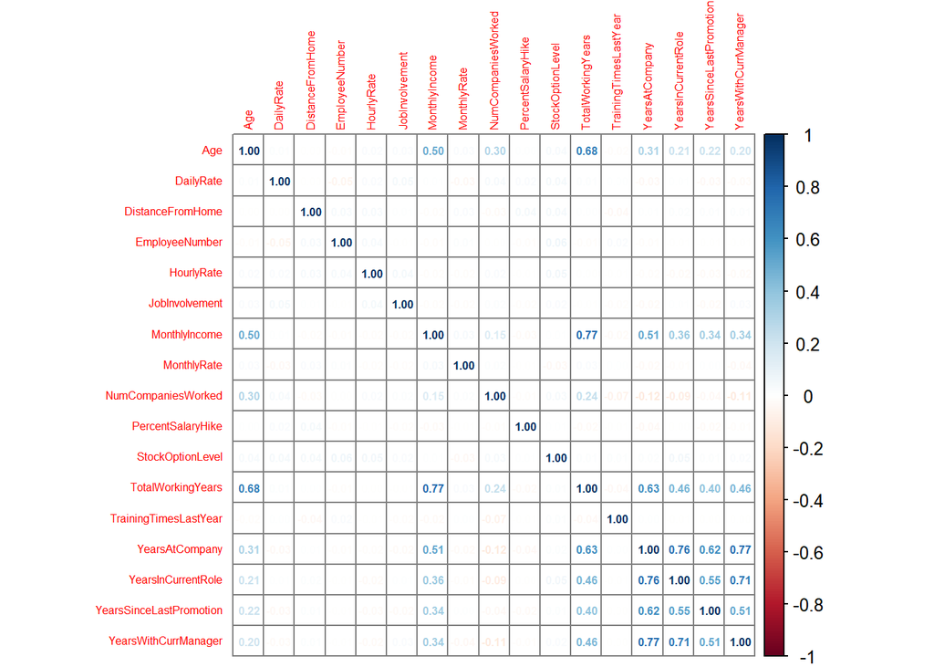

```r
#install.packages("corrplot")
library(psych)
library(corrplot)
#corPlot(cor(df_norm[(-1)]), cex=0.3, tl.cex=1, xlas=3)
corrplot(cor(df_norm[c(-1, -5, -13)], df_norm[c(-1, -5, -13)]),
         method = c("number"),
         #bg = "grey10",
         addgrid.col = "gray50",
         tl.cex=0.5,
         number.cex=0.5)
```

For this correlation plot, there are certain variables that has strong correlation (>0.5), this has to be dropped:

1. TotalWorkingYears
2. YearsAtCompany
3. YearsSinceLastPromotion
4. YearsWithCurentManager
5. Age

### Create Class Balanced Train and test Dataset

```r
#install.packages("caret")
library(caret)
'%ni%' = Negate('%in%')
options(scipen=999)

set.seed(100)
str(df_norm)
```

```
## 'data.frame':    1470 obs. of  20 variables:
##  $ Attrition              : Factor w/ 2 levels "0","1": 2 1 2 1 1 1 1 1 1 1 ...
##  $ Age                    : num  0.548 0.738 0.452 0.357 0.214 ...
##  $ DailyRate              : num  0.716 0.127 0.91 0.923 0.35 ...
##  $ DistanceFromHome       : num  0 0.25 0.0357 0.0714 0.0357 ...
##  $ EmployeeCount          : num  NaN NaN NaN NaN NaN NaN NaN NaN NaN NaN ...
##  $ EmployeeNumber         : num  0 0.000484 0.001451 0.001935 0.002903 ...
##  $ HourlyRate             : num  0.914 0.443 0.886 0.371 0.143 ...
##  $ JobInvolvement         : num  0.667 0.333 0.333 0.667 0.667 ...
##  $ MonthlyIncome          : num  0.2625 0.217 0.0569 0.1001 0.1295 ...
##  $ MonthlyRate            : num  0.6981 0.916 0.0121 0.8458 0.5837 ...
##  $ NumCompaniesWorked     : num  0.889 0.111 0.667 0.111 1 ...
##  $ PercentSalaryHike      : num  0 0.8571 0.2857 0 0.0714 ...
##  $ StandardHours          : num  NaN NaN NaN NaN NaN NaN NaN NaN NaN NaN ...
##  $ StockOptionLevel       : num  0 0.333 0 0 0.333 ...
##  $ TotalWorkingYears      : num  0.2 0.25 0.175 0.2 0.15 0.2 0.3 0.025 0.25 0.425 ...
##  $ TrainingTimesLastYear  : num  0 0.5 0.5 0.5 0.5 ...
##  $ YearsAtCompany         : num  0.15 0.25 0 0.2 0.05 0.175 0.025 0.025 0.225 0.175 ...
##  $ YearsInCurrentRole     : num  0.222 0.389 0 0.389 0.111 ...
##  $ YearsSinceLastPromotion: num  0 0.0667 0 0.2 0.1333 ...
##  $ YearsWithCurrManager   : num  0.294 0.412 0 0 0.118 ...
```

```r
df_train_test = df_norm[c(-2, -5, -6, -7, -10, -12, -13, -15, -17, -19, -20)]
head(df_train_test)
```

```
##   Attrition DailyRate DistanceFromHome JobInvolvement MonthlyIncome
## 1         1 0.7158196       0.00000000      0.6666667     0.2624539
## 2         0 0.1267001       0.25000000      0.3333333     0.2170090
## 3         1 0.9098067       0.03571429      0.3333333     0.0569247
## 4         0 0.9234073       0.07142857      0.6666667     0.1000527
## 5         0 0.3500358       0.03571429      0.6666667     0.1294892
## 6         0 0.6463851       0.03571429      0.6666667     0.1084255
##   NumCompaniesWorked StockOptionLevel TrainingTimesLastYear YearsInCurrentRole
## 1          0.8888889        0.0000000             0.0000000          0.2222222
## 2          0.1111111        0.3333333             0.5000000          0.3888889
## 3          0.6666667        0.0000000             0.5000000          0.0000000
## 4          0.1111111        0.0000000             0.5000000          0.3888889
## 5          1.0000000        0.3333333             0.5000000          0.1111111
## 6          0.0000000        0.0000000             0.3333333          0.3888889
```

```r
trainDataIndex= createDataPartition(df_train_test$Attrition, p=0.7, list = F)

trainData = df_train_test[trainDataIndex,]
testData = df_train_test[-trainDataIndex,]

# Down sample
set.seed(100)
down_train=downSample(x=trainData[, colnames(trainData)%ni%"Attrition"], y=trainData$Attrition)
table(down_train$Class)
```

```
##
##   0   1
## 166 166
```

```r
# Up Sample
set.seed(100)
up_train = upSample(x = trainData[, colnames(trainData)%ni%"Attrition"], y = trainData$Attrition)
table(up_train$Class)
```

```
##
##   0   1
## 864 864
```

### Create Logistic Regression Model

```r
logitmod = glm(Class~., family = "binomial", data=up_train)
summary(logitmod)
```

```
##
## Call:
## glm(formula = Class ~ ., family = "binomial", data = up_train)
##
## Deviance Residuals:
##     Min       1Q   Median       3Q      Max
## -2.3153  -1.0379   0.1485   0.9760   2.2668
##
## Coefficients:
##                       Estimate Std. Error z value             Pr(>|z|)
## (Intercept)             2.3276     0.2432   9.570 < 0.0000000000000002 ***
## DailyRate              -0.6187     0.1868  -3.313             0.000924 ***
## DistanceFromHome        0.8798     0.1859   4.734    0.000002204422823 ***
## JobInvolvement         -1.6891     0.2280  -7.408    0.000000000000128 ***
## MonthlyIncome          -2.1300     0.2887  -7.379    0.000000000000160 ***
## NumCompaniesWorked      0.8158     0.1920   4.250    0.000021353407819 ***
## StockOptionLevel       -1.1208     0.1917  -5.847    0.000000005013158 ***
## TrainingTimesLastYear  -1.1129     0.2636  -4.222    0.000024192264238 ***
## YearsInCurrentRole     -1.7893     0.3253  -5.501    0.000000037789440 ***
## ---
## Signif. codes:  0 '***' 0.001 '**' 0.01 '*' 0.05 '.' 0.1 ' ' 1
##
## (Dispersion parameter for binomial family taken to be 1)
##
##     Null deviance: 2395.5  on 1727  degrees of freedom
## Residual deviance: 2073.9  on 1719  degrees of freedom
## AIC: 2091.9
##
## Number of Fisher Scoring iterations: 4
```

### Model Validation using Accuracy Metrics

```r
pred <- predict(logitmod, testData, type = "response")

y_pred_num = ifelse(pred>0.5,1,0)
y_pred = factor(y_pred_num, levels=c(0,1))
y_act = testData$Attrition

mean(y_pred==y_act)
```

```
## [1] 0.6590909
```

## LDA Model

### Import Libraries

```r
library(MASS)
# install.packages("tidyverse")
library(tidyverse)
library(caret)
theme_set(theme_classic())
```

### Pre-processing Transformation

Center: substracts the mean of the predictor’s data (again from the data in x) from the predictor values  
Scale: divides by standard deviation

```r
preproc.parameter <- trainData %>%
  preProcess(method = c("center","scale"))
```

### Transform Train and Test Dataset

```r
train.transform <- preproc.parameter %>% predict(trainData)
test.transform <- preproc.parameter %>% predict(testData)
```

### Create LDA Model

```r
model <- lda(Attrition~., data = train.transform)
```

### Create Prediction from Test Dataset

```r
predictions <- model %>% predict(test.transform)
```

### Calculate Model Accuracy

```r
mean(predictions$class==test.transform$Attrition)
```

```
## [1] 0.8431818
```

### LDA Model Summary

```r
model <- lda(Attrition~., data = train.transform)
model
```

```
## Call:
## lda(Attrition ~ ., data = train.transform)
##
## Prior probabilities of groups:
##        0        1
## 0.838835 0.161165
##
## Group means:
##     DailyRate DistanceFromHome JobInvolvement MonthlyIncome NumCompaniesWorked
## 0  0.02297549      -0.03599539     0.06334745    0.07101548        -0.01919981
## 1 -0.11958325       0.18734951    -0.32971202   -0.36962271         0.09993156
##   StockOptionLevel TrainingTimesLastYear YearsInCurrentRole
## 0        0.0584063            0.02857815         0.07581069
## 1       -0.3039942           -0.14874409        -0.39458095
##
## Coefficients of linear discriminants:
##                              LD1
## DailyRate             -0.1401941
## DistanceFromHome       0.3151132
## JobInvolvement        -0.5023818
## MonthlyIncome         -0.4556619
## NumCompaniesWorked     0.1883235
## StockOptionLevel      -0.4331203
## TrainingTimesLastYear -0.2138637
## YearsInCurrentRole    -0.3746764
```